# 0_2-OpenDataSets

## We will introduce basic operations with examples, and then illustrate a few Python libraries that would be of relevance to data retrieval and data analysis.

## Numpy Scipy Pandas Matplotlib

## Source 1: Andryw Marques: How to show all columns/rows of a Pandas Dataframe?

## Source 2: Python Pandas 基本操作教學 (Chinese) https://medium.com/@weilihmen/python-pandas-%E5%9F%BA%E6%9C%AC%E6%93%8D%E4%BD%9C%E6%95%99%E5%AD%B8-%E6%88%90%E7%B8%BE%E8%A1%A8-f6d0ec4f89

## If you are a Stata user and would like to learn the Stata-Python integration, you may check this webpage http://www.danielmsullivan.com/pages/tutorial_stata_to_python.html

```python
# Basic operations on tuples and lists
# For tuples and lists, the + operator performs concatenation and * performs repetition.

x = [1,2,3]
y = [4,5,6]

print(x + y)

print(x * 3)
```

```
[1, 2, 3, 4, 5, 6]
[1, 2, 3, 1, 2, 3, 1, 2, 3]
```

```python
# create a long list of eights
x = [8] * 10

print(x)

# or an empty list
x = [None] * 10
print(x)
```

```
[8, 8, 8, 8, 8, 8, 8, 8, 8, 8]
[None, None, None, None, None, None, None, None, None, None]
```

```python
x + [2]
```

```
[None, None, None, None, None, None, None, None, None, None, 2]
```

```python
y = [10]*11
print(x + y)
```

```
[None, None, None, None, None, None, None, None, None, None, 10, 10, 10, 10, 10, 10, 10, 10, 10, 10, 10]
```

```python
del x[1:8]
print(x)
```

```
[None, None, None]
```

```python
z = [1,2,3, 4, 5, 6, 7, 8]
del z[1:5]
print(z)
```

```
[1, 6, 7, 8]
```

## Python List Append() Method

https://www.w3schools.com/python/ref_list_append.asp

```python
test_list = [1, 3, 4, 5]
test_str = 'abcde'
# Appending String to List
# using append()
test_list.append(test_str)

# printing result
print("The list after appending is : " + str(test_list))
```

```
The list after appending is : [1, 3, 4, 5, 'abcde']
```

```python
list1 = [2, 2, 2]
list2 = [1.5, 1.2, 1]
difference = []
# initialization of result list
'''Use zip(iterator1, iterator2) with the lists as iterator1 and iterator2 to return a zip object.
Use a for-loop to iterate over the zip object and subtract the lists' elements from each other
and store the result in a list. source: https://kite.com/python/answers/how-to-subtract-two-lists-in-python'''


zip_object = zip(list1, list2)
for list1_i, list2_i in zip_object:
    difference.append(list1_i-list2_i)

print(difference)
```

```
[0.5, 0.8, 1]
```

```python
sum_list = []
# initialize result list

for (item1, item2) in zip(list1, list2):
    sum_list.append(item1+item2)

print(sum_list)
```

```
[3.5, 3.2, 3]
```

```python
# if you attempt to execute the following scripts, Python would produce errors:
'''
x + 2
x - y
x / 2
'''
```

```
'\nx + 2\nx - y\nx / 2\n'
```

```python
x = [2,3, 45, 1]
x.sort()
print(x)
```

```
[1, 2, 3, 45]
```

```python
# Manipulating lists and dictionaries

# Recall that range() can be used to create a range of integers.
x = range(4,12,2)
print(list(x))
```

```
[4, 6, 8, 10]
```

```python
# decimals
x = [i/5 for i in range(20)]

print(x)
```

```
[0.0, 0.2, 0.4, 0.6, 0.8, 1.0, 1.2, 1.4, 1.6, 1.8, 2.0, 2.2, 2.4, 2.6, 2.8, 3.0, 3.2, 3.4, 3.6, 3.8]
```

```python
x = [3,2,6,4,12]
x_squared = [i**2 for i in x]
print(x_squared)
```

```
[9, 4, 36, 16, 144]
```

```python
# Reading and writing to files

# create some data to write to file
x = [1,2,3,4,5, 6]
y = range(1,7)
# check the difference between y and list(y)
# print(x, y)
# print(x, list(y))
x_squares = [i**2 for i in x]
colors = ['red','blue','yellow','green','red']

# convert x and squares to strings
x = [str(i) for i in x]
x_squares = [str(i) for i in x_squares]

print(x)
print(x_squares)
```

```
['1', '2', '3', '4', '5', '6']
['1', '4', '9', '16', '25', '36']
```

```python
def prod(x=1,y=2):
    return(x*y)

print(prod(), prod(2), prod(3,4))
```

```
2 4 12
```

```python
# Functions
def square(x):
    return(x**2)
print(square(4))

# The "" keyword argument tells the print function to end the line with an empty string, rather than a newline.
print("The squared value of 4 is: ", end="")
print(4*4)

import math
# Printing the log base e of 100
print ("Natural logarithm of 100 is : ", end="")
print (math.log(100))

# Printing the square
print(pow(4, 2))
```

```
16
The squared value of 4 is: 16
Natural logarithm of 100 is : 4.605170185988092
16
```

## NumPy Introduction

https://www.w3schools.com/python/numpy_intro.asp

## NumPy Creating Arrays

https://www.w3schools.com/python/numpy_creating_arrays.asp

## Joining NumPy Arrays: Joining means putting contents of two or more arrays in a single array.

https://www.w3schools.com/python/numpy_array_join.asp

```python
# it's standard practice to use the np prefix for numpy
import numpy as np

# Arrays
# Numpy arrays are convenient for representing vectors and matrices.

# np.arange creates an array rather than a range object or list

np.arange(10)

# np.arange also allows non-integer step sizes
```

```
array([0, 1, 2, 3, 4, 5, 6, 7, 8, 9])
```

```python
# Unlike Python lists, array operations are elementwise. We will see an error message
'''
x = np.array([1,2,3,5])
y = np.array([4,5,6])
print(x + y)
'''
```

```
'\nx = np.array([1,2,3,5])\ny = np.array([4,5,6])\nprint(x + y)\n'
```

```python
x = np.zeros([3,2])
y = np.ones([2,3])
z = np.diag([2, 2, 3])

print(x)
print(y)
print(z)

print(x, y, z)


# dtype provides information about Data-type of the array’s elements.
print(x.dtype)
print(z.dtype)
```

```
[[0. 0.]
 [0. 0.]
 [0. 0.]]
[[1. 1. 1.]
 [1. 1. 1.]]
[[2 0 0]
 [0 2 0]
 [0 0 3]]
[[0. 0.]
 [0. 0.]
 [0. 0.]] [[1. 1. 1.]
 [1. 1. 1.]] [[2 0 0]
 [0 2 0]
 [0 0 3]]
float64
int32
```

## NumPy Array Shaping & Reshaping

https://www.w3schools.com/python/numpy_array_shape.asp

https://www.w3schools.com/python/numpy_array_reshape.asp

```python
# Arrays can be reshaped to use as matrices.
# note the use of chain syntax; it's often useful to chain commands together

x = np.array([1,2,2,4,3,6]).reshape(3,2)
print(x)
```

```
[[1 2]
 [2 4]
 [3 6]]
```

```python
# note: x.dot(y) is equivalent to np.dot(x,y)
x = np.array([1,2,2,4,3,6]).reshape(3,2)
y = np.array([1, 1])
print(np.dot(x,y))

# Transpose a matrix:
x.T
''' array([[1, 2, 3],
       [2, 4, 6]]) '''
```

```
[3 6 9]
```

```
' array([[1, 2, 3],\n       [2, 4, 6]]) '
```

```python
# Matrix multiplication is a defined property of arrays

x = np.array([1,2,2,4,3,6]).reshape(3,2)
y = np.array([1,1])

print('x1:', x, '\n')
# we use '\n' to add a blank line in between
print('x2: ', x, '\n')
print('y: ', y, '\n')
print(x.dot(y))
```

```
x1: [[1 2]
 [2 4]
 [3 6]]

x2:  [[1 2]
 [2 4]
 [3 6]]

y:  [1 1]

[3 6 9]
```

## Scipy Introduction

https://docs.scipy.org/doc/scipy/reference/tutorial/general.html

## Matplotlib Introduction

https://matplotlib.org/api/pyplot_api.html

https://www.geeksforgeeks.org/python-introduction-matplotlib/

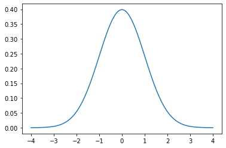

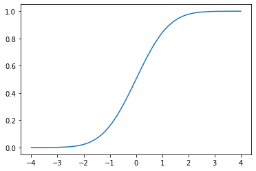

```python
# Random variables using the scipy package
# scipy has a lot more than just probability distributions; there are sub-libraries for topics such as linear algebra, optimization, etc.
# For more information about scipy see https://docs.scipy.org/doc/scipy/reference/.

from scipy import stats
# plot normal pdf
x = np.linspace(-4,4,100)
y = stats.norm().pdf(x)

import matplotlib.pyplot as plt

plt.plot(x,y)
plt.show()

# plot normal cdf
# (of course, you can also use this for Z tests, etc.)
x = np.linspace(-4,4,100)
y = stats.norm().cdf(x)

plt.plot(x,y)
plt.show()
```

```python
# generate random variables from a distribution
# (note: you can also do this in numpy using np.random)
x = stats.norm(10,4).rvs(3)
y = stats.expon(4).rvs(4)
z = stats.poisson(1).rvs(5)

print(x.round(2))
print(y.round(2))
print(z)
```

```
[12.94  3.85  9.44]
[5.77 5.31 4.52 4.83]
[1 0 2 3 1]
```

## pandas Introduction

### Brief pandas Intro https://www.geeksforgeeks.org/introduction-to-pandas-in-python/

### More pandas Details https://www.geeksforgeeks.org/pandas-tutorial/

### One more source for pandas: https://www.educative.io/edpresso/what-is-pandas-in-python

```python
# The pandas package provides its special objects and functions for easily reading in and manipulating data.
# For more information see http://pandas.pydata.org/pandas-docs/stable/.

import pandas as pd

x = pd.Series(stats.norm().rvs(10))
print(x.head())

# some of the many available summary statistics
[x.min(), x.quantile(0.25), x.median(), x.quantile(0.75), x.max(), x.mean(), x.var(), x.autocorr()]

# filter
x.where(x > 0)

# filter and remove missing values
x.where(x > 0).dropna()

# As with numpy arrays, operations are elementwise.
x + x

x ** 2

# Concatenate using append.
x2 = x.append(x)
print(x2.head())

# create using a dictionary
data1 = {'x': stats.uniform().rvs(10), 'y': stats.norm().rvs(10)}
df_data1 = pd.DataFrame(data1)
print(df_data1.head())

# create using a list
data2 = [stats.uniform().rvs(10),stats.norm().rvs(10)]
df_data2 = pd.DataFrame(data2)
print(df_data2.head())

# transpose
df_data2T = df_data2.T
print(df_data2T.head())
```

```
0   -0.711253
1   -0.320423
2   -0.909917
3   -1.026273
4    1.096429
dtype: float64
0   -0.711253
1   -0.320423
2   -0.909917
3   -1.026273
4    1.096429
dtype: float64
          x         y
0  0.392476  0.122586
1  0.050101  1.735715
```

[output cut: 16 more lines]

```python
# rename columns
df_data2T.columns = ['x','y']
print(df_data2T)

# pick out a column by name
df_data2T.x

# equivalent: df_data2T['x']

# Note that columns in a pandas DataFrame are Series objects.

type(df_data2T.x)
```

```
          x         y
0  0.513473  0.474783
1  0.988287 -0.731865
2  0.433501  0.346045
3  0.347002  0.649857
4  0.269838  0.556265
5  0.339320 -1.522525
6  0.383459 -1.637065
7  0.359122 -0.821661
8  0.418323  1.711760
9  0.315268  2.592554
```

```
pandas.core.series.Series
```

```python
# select columns by index
df2 = df_data2T.iloc[:,1]
print(df2)
```

```
0    0.474783
1   -0.731865
2    0.346045
3    0.649857
4    0.556265
5   -1.522525
6   -1.637065
7   -0.821661
8    1.711760
9    2.592554
Name: y, dtype: float64
```

```python
# select rows by index
df2 = df_data2T.iloc[0:5,]
print(df2)
```

```
          x         y
0  0.513473  0.474783
1  0.988287 -0.731865
2  0.433501  0.346045
3  0.347002  0.649857
4  0.269838  0.556265
```

```python
# select rows by value
df2 = df_data2T.where(df_data2T['x']>0.5,).dropna()
print(df2)
```

```
          x         y
0  0.513473  0.474783
1  0.988287 -0.731865
```

## Pandas Index.astype() function create an Index with values cast to dtypes. The class of a new Index is determined by dtype. When conversion is impossible, a ValueError exception is raised.

https://www.geeksforgeeks.org/python-pandas-index-astype/

## This example shows how to create a DataFrame from reading a .csv file in which the separation delimiter is a ; (semicolon 分號) with a coding format of gbk

## df_example = pd.read_csv('test.csv', encoding='gbk, sep=';')

```python
##  The basic command to convert a certain Python object (dictionary, lists etc) is
## pd.DataFrame()

## Use pandas read_csv header to specify which line in your data is to be considered as
## header.For example, the header is already present in the first line of our dataset
## shown below(note the bolded line).

## Use this argument to specify the row labels to use. If we set index_col to 0, then
## the first column of the dataframe will become the row label.

import pandas as pd # the to-be-created dataframe's name would be "data"
data = pd.read_excel("hsu2020.xlsx",encoding="utf-8-sig", index_col=0)

print(data)
```

```
                English  Math  Science  PE  Music
John Smith           65    92       78  83     70
Andy Wang            90    72       76  93     56
Jessica Python       81    85       91  89     77
Jimmy Gates          79    53       47  94     80
```

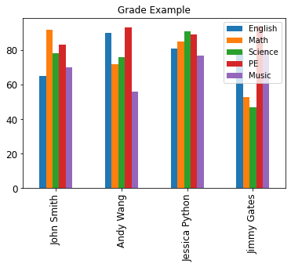

```python
datas = [[65,92,78,83,70], [90,72,76,93,56], [81,85,91,89,77], [79,53,47,94,80]]
indexs = ["John Smith", "Andy Wang", "Jessica Python", "Jimmy Gates"]
columns = ["English", "Math", "Science", "PE", "Music"]
df = pd.DataFrame(datas, columns=columns,  index=indexs)
df.plot(kind='bar', title='Grade Example', fontsize=12)
```